# NBAteamStats

## NBA Team Stat Exploration

```python
import pandas as pd
import numpy as np
import matplotlib.pyplot as plt
from matplotlib.patches import Rectangle
%matplotlib inline
import seaborn as sns
```

### 1) Dataset Cleanup

#### Import dataset and check column data types

```python
df = pd.read_csv('sample_data/nbaTeamStats.csv')
df.info()
```

```
<class 'pandas.core.frame.DataFrame'>
RangeIndex: 712 entries, 0 to 711
Data columns (total 29 columns):
 #   Column      Non-Null Count  Dtype
---  ------      --------------  -----
 0   year        712 non-null    object
 1   Unnamed: 1  712 non-null    int64
 2   TEAM        712 non-null    object
 3   GP          712 non-null    int64
 4   W           712 non-null    int64
 5   L           712 non-null    int64
 6   WIN%        712 non-null    float64
 7   MIN         712 non-null    float64
 8   PTS         712 non-null    float64
 9   FGM         712 non-null    float64
```

[output cut: 21 more lines]

#### Replace franchises with multiple names/locations to the most current name

```python
# Teams to combine
# New Orleans Hornets, New Orleans Pelicans, New Orleans/Oklahoma City Hornets
# Charlotte Bobcats, Charlotte Hornets
# Brooklyn Nets, New Jersey Nets
# LA Clippers, Los Angeles Clippers
# Vancouver Grizzlies, Memphis Grizzlies
# Seattle SuperSonics, Oklahoma City Thunder
# Washington Bullets, Washington Wizards
```

```python
# Combined Team Names
df1 = df.copy()
df1['TEAM'].replace(['New Orleans Hornets', 'New Orleans/Oklahoma City Hornets'], 'New Orleans Pelicans', inplace=True)
df1['TEAM'].replace(['Charlotte Bobcats'], 'Charlotte Hornets', inplace=True)
df1['TEAM'].replace(['New Jersey Nets'], 'Brooklyn Nets', inplace=True)
df1['TEAM'].replace(['Los Angeles Clippers'], 'LA Clippers', inplace=True)
df1['TEAM'].replace(['Vancouver Grizzlies'], 'Memphis Grizzlies', inplace=True)
df1['TEAM'].replace(['Seattle SuperSonics'], 'Oklahoma City Thunder', inplace=True)
df1['TEAM'].replace(['Washington Bullets'], 'Washington Wizards', inplace=True)
```

#### Add champion, playoffs, division, and conference categories

```python
team_info = [{'name': 'Atlanta Hawks', 'conf': 'east', 'div': 'southeast'},
 {'name': 'Boston Celtics', 'conf': 'east', 'div': 'atlantic'},
 {'name': 'Brooklyn Nets', 'conf': 'east', 'div': 'atlantic'},
 {'name': 'Charlotte Hornets', 'conf': 'east', 'div': 'southeast'},
 {'name': 'Chicago Bulls', 'conf': 'east', 'div': 'central'},
 {'name': 'Cleveland Cavaliers', 'conf': 'east', 'div': 'central'},
 {'name': 'Dallas Mavericks', 'conf': 'west', 'div': 'southwest'},
 {'name': 'Denver Nuggets', 'conf': 'west', 'div': 'northwest'},
 {'name': 'Detroit Pistons', 'conf': 'east', 'div': 'central'},
 {'name': 'Golden State Warriors', 'conf': 'west', 'div': 'pacific'},
 {'name': 'Houston Rockets', 'conf': 'west', 'div': 'southwest'},
 {'name': 'Indiana Pacers', 'conf': 'east', 'div': 'central'},
 {'name': 'LA Clippers', 'conf': 'west', 'div': 'pacific'},
 {'name': 'Los Angeles Lakers', 'conf': 'west', 'div': 'pacific'},
 {'name': 'Memphis Grizzlies', 'conf': 'west', 'div': 'southwest'},
 {'name': 'Miami Heat', 'conf': 'east', 'div': 'southeast'},
 {'name': 'Milwaukee Bucks', 'conf': 'east', 'div': 'central'},
 {'name': 'Minnesota Timberwolves', 'conf': 'west', 'div': 'northwest'},
 {'name': 'New Orleans Pelicans', 'conf': 'west', 'div': 'southwest'},
 {'name': 'New York Knicks', 'conf': 'east', 'div': 'atlantic'},
 {'name': 'Oklahoma City Thunder', 'conf': 'west', 'div': 'northwest'},
 {'name': 'Orlando Magic', 'conf': 'east', 'div': 'southeast'},
 {'name': 'Philadelphia 76ers', 'conf': 'east', 'div': 'atlantic'},
 {'name': 'Phoenix Suns', 'conf': 'west', 'div': 'pacific'},
 {'name': 'Portland Trail Blazers', 'conf': 'west', 'div': 'northwest'},
 {'name': 'Sacramento Kings', 'conf': 'west', 'div': 'pacific'},
 {'name': 'San Antonio Spurs', 'conf': 'west', 'div': 'southwest'},
 {'name': 'Toronto Raptors', 'conf': 'east', 'div': 'atlantic'},
 {'name': 'Utah Jazz', 'conf': 'west', 'div': 'northwest'},
 {'name': 'Washington Wizards', 'conf': 'east', 'div': 'southeast'}]

champions = {'1996-97': 'Chicago Bulls', '1997-98':'Chicago Bulls', '1998-99':'San Antonio Spurs',
             '1999-00':'Los Angeles Lakers','2000-01':'Los Angeles Lakers','2001-02':'Los Angeles Lakers',
             '2002-03':'San Antonio Spurs', '2003-04':'Detroit Pistons', '2004-05':'San Antonio Spurs',
             '2005-06':'Miami Heat','2006-07':'San Antonio Spurs', '2007-08':'Bostom Celtics',
             '2008-09':'Los Angeles Lakers','2009-10':'Los Angeles Lakers','2010-11':'Dallas Mavericks',
             '2011-12':'Miami Heat','2012-13':'Miami Heat','2013-14':'San Antonio Spurs',
             '2014-15':'Golden State Warriors','2015-16':'Cleveland Cavaliers','2016-17':'Golden State Warriors',
             '2017-18':'Golden State Warriors','2018-19':'Toronto Raptors', '2019-20':'None'}
```

```python
# Map the conference, division, and championship data from cell above
# to new columns in the dataset

def get_teamInfo(row, category):
    '''Function to map conference and division info'''
    obj = list(filter(lambda x: x['name'] == row['TEAM'], team_info))[0]
    return obj[category]

def is_champion(row):
    '''Function to map yearly league champion info'''
    if champions[row['year']] == row['TEAM']:
        return 1

df1['conference'] = df1.apply(lambda x: get_teamInfo(x, 'conf'), axis=1)
df1['division'] = df1.apply(lambda x: get_teamInfo(x, 'div'), axis=1)
df1['champion'] = df1.apply(is_champion, axis=1)
```

### 2) Create New DataFrames For Plotting

#### Create a pivoted table with grouped team info and years as columns

```python
# Use year and Team for grouping and unstack the year to column
winPercent = df1[['year','TEAM','WIN%']]
df2 = winPercent.groupby(['TEAM','year']).sum().unstack()
# droplevel (just for aesthetic purposes)
df2.columns = df2.columns.droplevel()
df2.head(2)
```

| year TEAM | 1996-97 | 1997-98 | 1998-99 | 1999-00 | 2000-01 | 2001-02 | 2002-03 | 2003-04 | 2004-05 | 2005-06 | ... | 2010-11 | 2011-12 | 2012-13 | 2013-14 | 2014-15 | 2015-16 | 2016-17 | 2017-18 | 2018-19 | 2019-20 |
| --- | --- | --- | --- | --- | --- | --- | --- | --- | --- | --- | --- | --- | --- | --- | --- | --- | --- | --- | --- | --- | --- |
| Atlanta Hawks | 0.683 | 0.610 | 0.62 | 0.341 | 0.305 | 0.402 | 0.427 | 0.341 | 0.159 | 0.317 | ... | 0.537 | 0.606 | 0.537 | 0.463 | 0.732 | 0.585 | 0.524 | 0.293 | 0.354 | 0.299 |
| Boston Celtics | 0.183 | 0.439 | 0.38 | 0.427 | 0.439 | 0.598 | 0.537 | 0.439 | 0.549 | 0.402 | ... | 0.683 | 0.591 | 0.506 | 0.305 | 0.488 | 0.585 | 0.646 | 0.671 | 0.598 | 0.672 |

2 rows × 24 columns

#### Create another pivoted table similar to above, but with Win counts instead to

#### use for annotations on the heatmap

```python
a = df1[['year','TEAM','W']]
a = a.groupby(['TEAM','year']).sum().unstack()
a.columns = a.columns.droplevel()
a.head(2)
```

| year TEAM | 1996-97 | 1997-98 | 1998-99 | 1999-00 | 2000-01 | 2001-02 | 2002-03 | 2003-04 | 2004-05 | 2005-06 | ... | 2010-11 | 2011-12 | 2012-13 | 2013-14 | 2014-15 | 2015-16 | 2016-17 | 2017-18 | 2018-19 | 2019-20 |
| --- | --- | --- | --- | --- | --- | --- | --- | --- | --- | --- | --- | --- | --- | --- | --- | --- | --- | --- | --- | --- | --- |
| Atlanta Hawks | 56.0 | 50.0 | 31.0 | 28.0 | 25.0 | 33.0 | 35.0 | 28.0 | 13.0 | 26.0 | ... | 44.0 | 40.0 | 44.0 | 38.0 | 60.0 | 48.0 | 43.0 | 24.0 | 29.0 | 20.0 |
| Boston Celtics | 15.0 | 36.0 | 19.0 | 35.0 | 36.0 | 49.0 | 44.0 | 36.0 | 45.0 | 33.0 | ... | 56.0 | 39.0 | 41.0 | 25.0 | 40.0 | 48.0 | 53.0 | 55.0 | 49.0 | 43.0 |

2 rows × 24 columns

#### Plot the heatmap (extra step to highlight yearly champions)

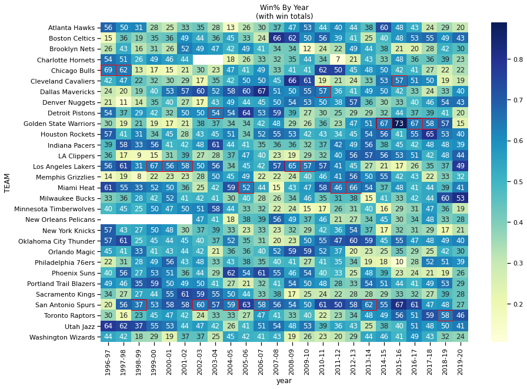

```python
fig = plt.figure(figsize=(14,10))

# plot the heatmap with data from pivoted Win% dataframe
# include Win count dataframe for the annotations
# this will plot the heatmap based on win% but show the win count as it's easier to read
# (TODO: normalize years with under 82 games using win% so win counts aren't skewed)
ax = sns.heatmap(data=df2, cmap="YlGnBu", annot=a)

# Create a third pivoted dataframe using 'champions' to highlight champs in heatmap
b = df1[['year','TEAM','champion']]
b = b.groupby(['TEAM','year']).sum().unstack()
b.columns = b.columns.droplevel()

# Set empty array to store indices of champs
champ_indices = []
# Loop through each row and then value of the pivoted champions dataframe
# storing the indices in order to highlight them
for i, row in enumerate(b.values):
    for j, val in enumerate(row):
        if val == 1:
            champ_indices.append((j,i))

# Loop through indices and apply red border to each one
for coords in champ_indices:
    ax.add_patch(Rectangle(coords,1,1, edgecolor='red'))

ax.set_title('Win% By Year\n(with win totals)')

plt.show()
```

#### Observations

- Spurs have been good the most consistently over this time period
- Outside of the Spurs, it's hard to stay really good for more than a few years in a row
- Some of the worst stretches in this time period:
  - Bulls after Jordan left
  - Grizzlies and Warriors through 2003
  - T-Wolves after KG left
  - Kings after Bibby left
  - Wizards 2008-2014
  - Lakers after Kobe got hurt
  - 76ers 2013-2017

### 3) Further exploration

#### Create a correlation matrix and plot to check which stats are highly correlated

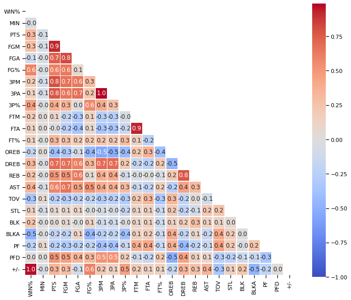

```python
# Correlation Matrix
corr_matrix = df1[['WIN%', 'MIN', 'PTS',
       'FGM', 'FGA', 'FG%', '3PM', '3PA', '3P%', 'FTM', 'FTA', 'FT%', 'OREB',
       'DREB', 'REB', 'AST', 'TOV', 'STL', 'BLK', 'BLKA', 'PF', 'PFD', '+/-']].corr()

fig, ax = plt.subplots(figsize=(12,10))
dropSelf = np.zeros_like(corr_matrix)
dropSelf[np.triu_indices_from(dropSelf)] = True
sns.heatmap(corr_matrix, vmin=-1, cmap='coolwarm', linewidths=.5, square=True,
                annot=True, fmt=".1f", mask=dropSelf)
plt.show()
```

#### Observations:

- The highest correlation (other than +/- which is obvious) for Win% out of these basic team stats is FG%. This makes intuitive sense since missing fewest shots possible is advantageous, but it is interesting that it is a better predictor than PTS
- Several obvious very high correlations e.g. FTM and FTA
- Interesting one that sticks out: DREB is highly correlated with PTS, FGM, 3PM, and 3PA. Is this simply that when there are many rebounds to be had there are more shots going up and thus more baskets made?

#### Scatter plots and regression lines

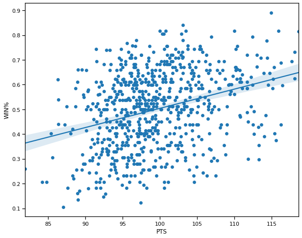

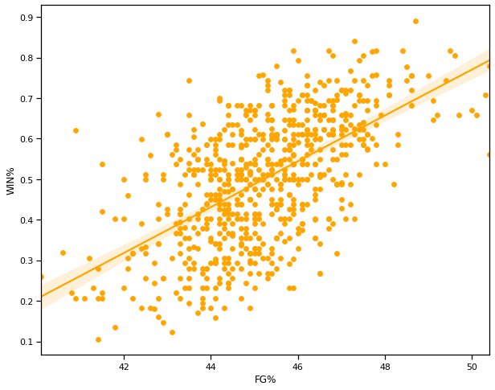

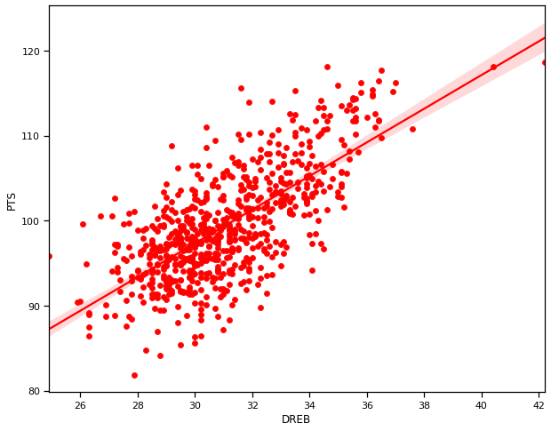

```python
fig, ax = plt.subplots(figsize=(10,8))
ax = sns.scatterplot(x=df1['PTS'], y=df1['WIN%'])
sns.regplot(x=df1['PTS'], y=df1['WIN%'])

fig, ax = plt.subplots(figsize=(10,8))
ax = sns.scatterplot(x=df1['FG%'], y=df1['WIN%'], color='orange')
sns.regplot(x=df1['FG%'], y=df1['WIN%'], color='orange')

fig, ax = plt.subplots(figsize=(10,8))
ax = sns.scatterplot(x=df1['DREB'], y=df1['PTS'], color='red')
sns.regplot(x=df1['DREB'], y=df1['PTS'], color='red')

plt.show()
```

#### Bring in Playoff Data

```python
dfp = pd.read_csv('sample_data/nbaTeamStatsPlayoffs.csv')
del dfp['Unnamed: 1']
dfp.head(1)
```

|  | year | TEAM | GP | W | L | WIN% | MIN | PTS | FGM | FGA | ... | DREB | REB | AST | TOV | STL | BLK | BLKA | PF | PFD | +/- |
| --- | --- | --- | --- | --- | --- | --- | --- | --- | --- | --- | --- | --- | --- | --- | --- | --- | --- | --- | --- | --- | --- |
| 0 | 2018-19 | Utah Jazz | 5 | 1 | 4 | 0.2 | 48.0 | 97.8 | 34.6 | 86.4 | ... | 35.4 | 47.2 | 23.0 | 15.2 | 9.2 | 5.4 | 7.0 | 21.8 | 21.4 | -9.2 |

1 rows × 28 columns

```python
## Get rid of alternate names
dfp1 = dfp.copy()
dfp1['TEAM'].replace(['New Orleans Hornets', 'New Orleans/Oklahoma City Hornets'], 'New Orleans Pelicans', inplace=True)
dfp1['TEAM'].replace(['Charlotte Bobcats'], 'Charlotte Hornets', inplace=True)
dfp1['TEAM'].replace(['New Jersey Nets'], 'Brooklyn Nets', inplace=True)
dfp1['TEAM'].replace(['Los Angeles Clippers'], 'LA Clippers', inplace=True)
dfp1['TEAM'].replace(['Vancouver Grizzlies'], 'Memphis Grizzlies', inplace=True)
dfp1['TEAM'].replace(['Seattle SuperSonics'], 'Oklahoma City Thunder', inplace=True)
dfp1['TEAM'].replace(['Washington Bullets'], 'Washington Wizards', inplace=True)
```

```python
dfp1.head(1)
```

|  | year | TEAM | GP | W | L | WIN% | MIN | PTS | FGM | FGA | ... | DREB | REB | AST | TOV | STL | BLK | BLKA | PF | PFD | +/- |
| --- | --- | --- | --- | --- | --- | --- | --- | --- | --- | --- | --- | --- | --- | --- | --- | --- | --- | --- | --- | --- | --- |
| 0 | 2018-19 | Utah Jazz | 5 | 1 | 4 | 0.2 | 48.0 | 97.8 | 34.6 | 86.4 | ... | 35.4 | 47.2 | 23.0 | 15.2 | 9.2 | 5.4 | 7.0 | 21.8 | 21.4 | -9.2 |

1 rows × 28 columns

```python
## Merge Reg and Playoff Data
dfbig = df1.merge(dfp1, how='outer', on=['year','TEAM'], suffixes=('','_p'))
```

```python
big_piv = dfbig[['year','TEAM','W_p']].dropna().groupby(['TEAM','year']).sum().unstack()
big_piv.columns = big_piv.columns.droplevel()
big_piv.head(1)
```

| year TEAM | 1996-97 | 1997-98 | 1998-99 | 1999-00 | 2000-01 | 2001-02 | 2002-03 | 2003-04 | 2004-05 | 2005-06 | ... | 2009-10 | 2010-11 | 2011-12 | 2012-13 | 2013-14 | 2014-15 | 2015-16 | 2016-17 | 2017-18 | 2018-19 |
| --- | --- | --- | --- | --- | --- | --- | --- | --- | --- | --- | --- | --- | --- | --- | --- | --- | --- | --- | --- | --- | --- |
| Atlanta Hawks | 4.0 | 1.0 | 3.0 | NaN | NaN | NaN | NaN | NaN | NaN | NaN | ... | 4.0 | 6.0 | 2.0 | 2.0 | 3.0 | 8.0 | 4.0 | 2.0 | NaN | NaN |

1 rows × 23 columns

#### Team Playoff Wins by Year heatmap

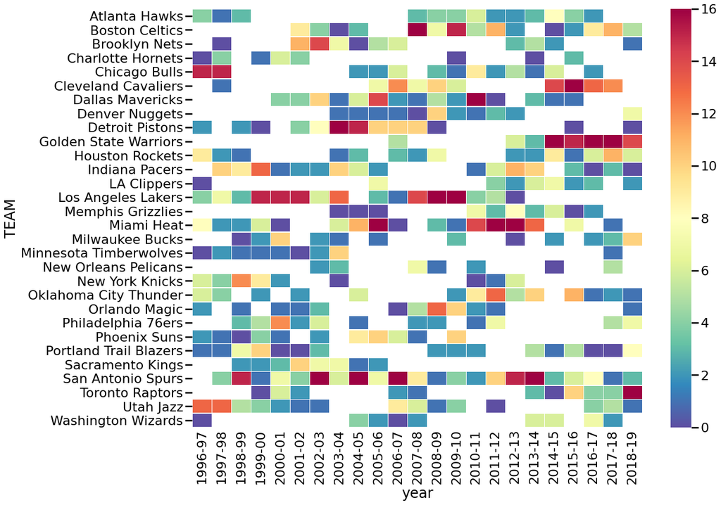

```python
fig, ax = plt.subplots(figsize=(17,13))
ax = sns.heatmap(big_piv, cmap="Spectral_r", linewidths=.5)
ax.tick_params(axis='x', length=0)
sns.set_context('poster')
```